# Lab 6 - Planks Constant

## Objectives

The objective of this lab is to understand the physics behind the photo electric effect and the energy of photons. We should be able to show experimentally how to find planks constant, determin the work function of an unknown material, and demonstrate the fact that intensity does not affect the current produced by the photoelectric effect. It should build intuition for how photons can be used in experiments in combination with plank's constant to find energy of events that produce photons.

## Background

In the late 1800s to early 1900s physicists were starting to look into the quantum nature of the universe. Plank claimed that there were discrete sets of energy levels for certain events, and when these events occured they were either triggered by *quanta* with the value of energy needed for the event or a quanta was released with that energy. If the energy were released in the form of light, that implied that the light quanta, or photons, has exactly the energy given by the event they were prouced by.

Also in the early 1900s the photoelectric effect was discovered, which also talked about photon energy. It said that when photons hit metal, they would produce electrons with the kinetic energy of the photons minus some constant that was dependant on the metal, called the work function of the material. This effect showed that the number of photons did not effect the energy of each electron, so the energy of a photons is only dependant on the wavelength/frequency.

The actual energy of the photon is given by $ E = h \nu $ where $h$ is planks constant, a constant of nature, and $\nu$ is the frequency of a photon.

Plank was correct that there are discrete energy levels, and we can see evidence of that from atomic spectral lines. They only release certain photons, which we will take advantage of also.

## Experiment

The experiment is done using a light source (Hg vapor light source), a metal (the source of electron from the photoelectric effect), and a volt meter (to measure the current caused by the photoelectric effect). We use the Hg as a light source because we can make spectral lines that we know the wavelength of (and by extension the frequencies). We will use known values of the pectral lines of Hg, but in theory we could also use planks constant to determine the wavelengths of Hg's emission spectrum.

The setup is:

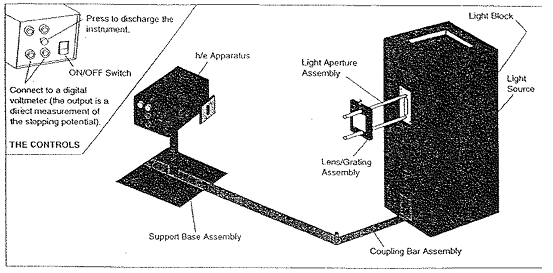

The light coming from the Hg is certain wavelength, but there are multiple lines, we will use the first order and second order lines coming off. They look something like this:

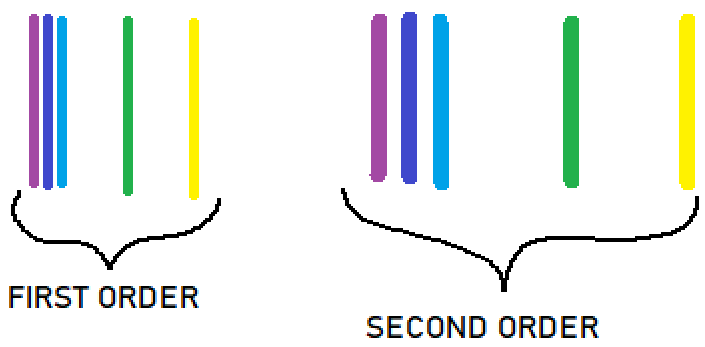

The second order lines are not as focused, and are more spaced out.

We recieve the light into this:

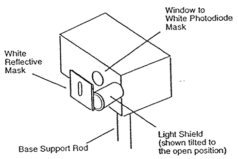

Which is powered by a 9V battery and has an output to the volt meter.

We have two parts of the experiment:

Part **(A)** is showing that the intensity of the light does in fact not affect the voltage output. We do this by using the green and yellow spectral lines and some filters. Whenever we use the green or yellow lines we use green and yellow filters help isolate the photons that are making it into the aparatus, improving our resolution. We also hace a filter to block an certain percentage of all photons. By filtering out 0%-80% of the light going into the aparatus we can show that the intensity does not matter.

Part **(B)** is measuring planks constant and the work function of the material we are using in tandem with the photoelectric effect. We will measure the voltage that results from the light shining on the apparatus for each of the spectral lines (both first and second order). Then plot the results to find $h$ and the work function.

## Data

```python
import numpy as np

orange_p = [100, 80, 60, 40, 20]
orange = [0.715, 0.714, 0.714, 0.715, 0.716]
orange_t = [3, 7.0, 3.3, 3.4, 2.9]

green_p = [100, 80, 60, 40, 20]
green = [0.847, 0.846, 0.846, 0.846, 0.846]
green_t = [4.2, 6.4, 6.7, 6.7, 5.8]

freqs = np.array([5.18672e14, 5.48996e14, 6.87858e14, 7.40858e14, 8.20264e14]) #Hz
voltage_labels = ["yellow", "green", "blue", "violet", "uv"]
order1_1 = [0.715, 0.846, 1.472, 1.693, 2.012]
order1_2 = [0.717, 0.850, 1.478, 1.695, 2.022]
order2_1 = [0.742, 1.217, 1.496, 1.693, 2.006]
order2_2 = [0.733, 1.222, 1.492, 1.688, 2.005]
```

First we want to ensure that the kinetic energy does not change when intensity changes. That would break our entire theory.

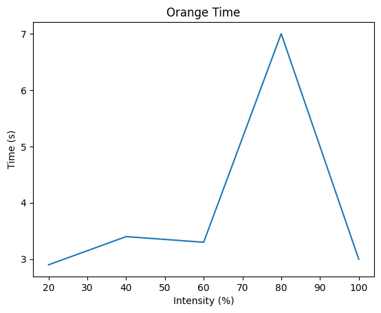

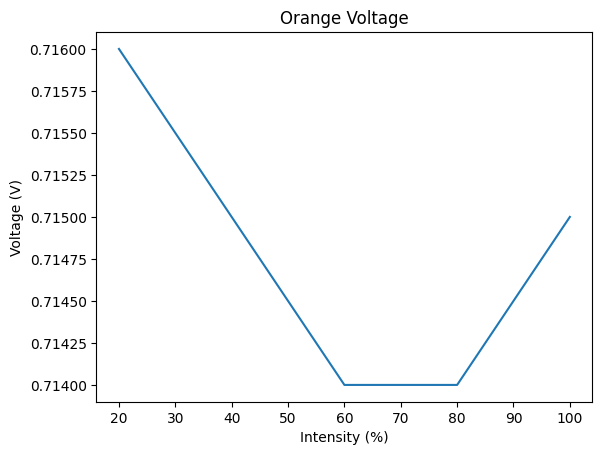

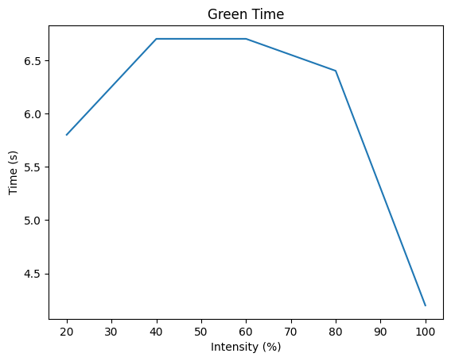

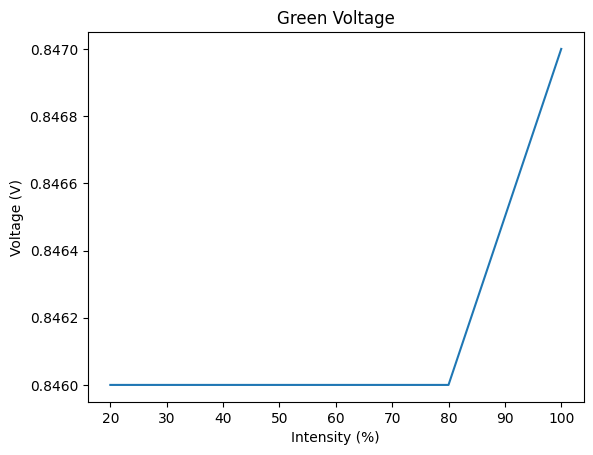

```python
import matplotlib.pyplot as plt

plt.plot(orange_p, orange_t)
plt.title("Orange Time")
plt.xlabel("Intensity (%)")
plt.ylabel("Time (s)")
plt.show()

plt.plot(orange_p, orange)
plt.title("Orange Voltage")
plt.xlabel("Intensity (%)")
plt.ylabel("Voltage (V)")
plt.show()

plt.plot(green_p, green_t)
plt.title("Green Time")
plt.xlabel("Intensity (%)")
plt.ylabel("Time (s)")
plt.show()

plt.plot(green_p, green)
plt.title("Green Voltage")
plt.xlabel("Intensity (%)")
plt.ylabel("Voltage (V)")
plt.show()
```

From above we can see that the voltage graphs do what we expect, they remain mostly constant despite the change in intensity. This is because the energy in each electron ejected from the metal is given by $ hf - \Phi_0 = T = eV $ which does not have any term for intensity present.

The time graphs represent the time it takes for the volt meter to measure current. We do expect that higher intensity means it will recognize current fast, since there are more electrons and those electron will have a higher change to ge to the metal. We do see it dips down for low intensity, but that does not explain the dip at high intenisty. This is probably due to either a slow voltmeter, or some sort of experimental error we accidentally introduced. Either way we believe there is enough reason to continue the experiment based on the constant votlage.

```python
from typing import Callable
import matplotlib.pyplot as plt

def mean(xs:list[float]) -> float:
    s = sum([x for x in xs]) # list comprehension will follow the pattern and the sum just adds
    N = len(xs) # length of xs
    return s/N

def std(xs:list[float]) -> float:
    xbar = mean(xs)
    s = sum([(x-xbar)**2 for x in xs])
    N = len(xs)
    return np.sqrt(s/(N-1)) # we use N-1 for the bias corrected version

# this function is the DELTA in the formula
def delta(xs, ys, stds) -> float:
    a = sum([1/sig**2 for sig in stds])
    b = sum([x**2/sig**2 for sig, x in zip(stds, xs)])
    c = sum([x/sig**2 for sig, x in zip(stds, xs)])
    return a*b - c**2

# this calculates the m hat in the formula
def m_fit(xs, ys, stds) -> float:
    a = sum([1/sig**2 for sig in stds])
    b = sum([x*y/sig**2 for x, y, sig in zip(xs,ys,stds)])
    c = sum([x/sig**2 for x, sig in zip(xs,stds)])
    d = sum([y/sig**2 for y, sig in zip(ys,stds)])
    return (a*b - c*d)/delta(xs, ys, stds)

# this calculates the b hat in the formula
def b_fit(xs, ys, stds) -> float:
    a = sum([x**2/sig**2 for x, sig in zip(xs, stds)])
    b = sum([y/sig**2 for y, sig in zip(ys,stds)])
    c = sum([x/sig**2 for x, sig in zip(xs,stds)])
    d = sum([x*y/sig**2 for x, y, sig in zip(xs,ys,stds)])
    return (a*b - c*d)/delta(xs, ys, stds)

# returns a function in the form f(x) = mx + b
def fit_line(xs, ys, stds) -> Callable:
    m = m_fit(xs,ys,stds)
    b = b_fit(xs,ys,stds)
    f = lambda x: m*x + b
    return f

# uncertainty in b
def sigma_m(xs, ys, stds) -> float:
    a = sum([1/sig**2 for sig in stds])
    return np.sqrt(a/delta(xs, ys, stds))

# uncertainty in m
def sigma_b(xs, ys, stds) -> float:
    a = sum([x**2/sig**2 for x, sig in zip(xs, stds)])
    return np.sqrt(a/delta(xs, ys, stds))
```

```python
from tabulate import tabulate

vals = np.array([order1_1, order1_2, order2_1, order2_2])

avgs = np.array(mean(vals))
v_unc = np.array(std(vals))
freqs = np.array([5.18672e14, 5.48996e14, 6.87858e14, 7.40858e14, 8.20264e14]) #Hz

sides = ["freq (Hz)", "trial 1 (V)", "trial 2 (V)", "trial 3 (V)", "trial 4 (V)", "average (V)", "v_unc (V)"]
voltage_labels = ["yellow", "green", "blue", "violet", "uv"]
t = np.array([freqs, order1_1, order1_2, order2_1, order2_2, avgs, v_unc])
print(tabulate(t, headers=voltage_labels, showindex=sides,))
```

```
                  yellow        green         blue       violet           uv
-----------  -----------  -----------  -----------  -----------  -----------
freq (Hz)    5.18672e+14  5.48996e+14  6.87858e+14  7.40858e+14  8.20264e+14
trial 1 (V)  0.715        0.846        1.472        1.693        2.012
trial 2 (V)  0.717        0.85         1.478        1.695        2.022
trial 3 (V)  0.742        1.217        1.496        1.693        2.006
trial 4 (V)  0.733        1.222        1.492        1.688        2.005
average (V)  0.72675      1.03375      1.4845       1.69225      2.01125
v_unc (V)    0.0129711    0.214502     0.0113578    0.00298608   0.00780491
```

$$ E = hf = T + \Phi_0 $$$$ T = eV $$$$ hf = eV + \Phi_0 $$$$ V = \frac{h}{e}f - \frac{\Phi_0}{e} $$

```
[5.18672e+14 5.48996e+14 6.87858e+14 7.40858e+14 8.20264e+14]
[0.72675 1.03375 1.4845  1.69225 2.01125]
[0.01297112 0.21450155 0.01135782 0.00298608 0.00780491]
```

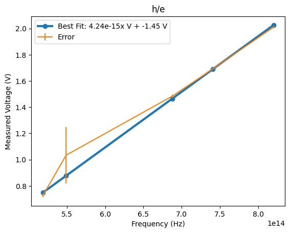

```
The value of b for the best fit line is -1.4.
The value of m for the best fit line is 4.2e-15.
The uncertainty of b for the best fit line is 0.036.
The uncertainty of m for the best fit line is 4.9e-17.
```

```python
x = np.array(freqs)
y = np.array(avgs)
stds = np.array(v_unc)

print(x)
print(y)
print(stds)

args = (x, y, stds)
f = fit_line(*args)
m = m_fit(*args)
b = b_fit(*args)

plt.plot(x, f(x), "-o",  linewidth=3)
plt.errorbar(x, y, stds)
plt.title("h/e")
plt.legend([f"Best Fit: {m:.3}x V + {b:.3} V", "Error"])
plt.xlabel("Frequency (Hz)")
plt.ylabel("Measured Voltage (V)")
plt.show()

print(f"The value of b for the best fit line is {b_fit(x, y, stds):.2}.")
print(f"The value of m for the best fit line is {m_fit(x, y, stds):.2}.")
m = m_fit(x, y, stds)

print(f"The uncertainty of b for the best fit line is {sigma_b(x, y, stds):.2}.")
print(f"The uncertainty of m for the best fit line is {sigma_m(x, y, stds):.2}.")
```

In that plot we can see from the equation that $ m = \dfrac{h}{e} $ and $ b = -\dfrac{\Phi_0}{e} $. We also can find that the elementrary charge $ e = 1.602176634 \times 10^{-19} C $.

```python
e = 1.602176634e-19
h = m * e
workF = -b * e
print(f"h = {h} J*s")
print(f"WorkF = {workF} J")

h_real = 6.62607015e-34

print(f"The accepted value for h is {h_real}")
print(f"Relative error: {(h_real-h)/h_real}")
```

```
h = 6.790859525029904e-34 J*s
WorkF = 2.323103768362591e-19 J
The accepted value for h is 6.62607015e-34
Relative error: -0.02486985065044991
```

We see that the green examples are wildy off from eachother, so we will see what happens when we exclude this form the calculation.

```
[5.18672e+14 5.48996e+14 6.87858e+14 7.40858e+14 8.20264e+14]
[0.72675 1.4845  1.69225 2.01125]
[0.01297112 0.01135782 0.00298608 0.00780491]
```

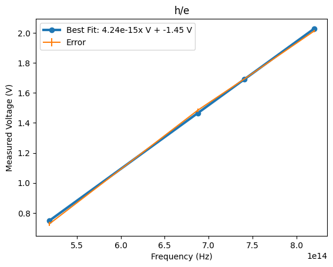

```
The value of b for the best fit line is -1.5.
The value of m for the best fit line is 4.2e-15.
The uncertainty of b for the best fit line is 0.036.
The uncertainty of m for the best fit line is 4.9e-17.
```

```python
def rem1(ls):
    return [x for i,x in enumerate(ls) if i != 1]

x = np.array(rem1(freqs))
y = np.array(rem1(avgs))
stds = np.array(rem1(v_unc))

print(freqs)
print(y)
print(stds)

args = (x, y, stds)
f = fit_line(*args)
m = m_fit(*args)
b = b_fit(*args)

plt.plot(x, f(x), "-o",  linewidth=3)
plt.errorbar(x, y, stds)
plt.title("h/e")
plt.legend([f"Best Fit: {m:.3}x V + {b:.3} V", "Error"])
plt.xlabel("Frequency (Hz)")
plt.ylabel("Measured Voltage (V)")
plt.show()

print(f"The value of b for the best fit line is {b_fit(x, y, stds):.2}.")
print(f"The value of m for the best fit line is {m_fit(x, y, stds):.2}.")
m = m_fit(x, y, stds)

print(f"The uncertainty of b for the best fit line is {sigma_b(x, y, stds):.2}.")
print(f"The uncertainty of m for the best fit line is {sigma_m(x, y, stds):.2}.")
```

```python
e = 1.602176634e-19
h = m * e
workF = -b * e
print(f"h = {h} J*s")
print(f"WorkF = {workF} J")

h_real = 6.62607015e-34

print(f"The accepted value for h is {h_real}")
print(f"Relative error: {(h_real-h)/h_real}")
```

```
h = 6.793329675351338e-34 J*s
WorkF = 2.3249647461216964e-19 J
The accepted value for h is 6.62607015e-34
Relative error: -0.02524264331118467
```

We can also see if there is a difference between the first order or second order spectral lines.

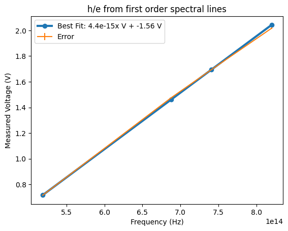

```
The value of b for the best fit line is -1.6.
The value of m for the best fit line is 4.4e-15.
The uncertainty of b for the best fit line is 0.0056.
The uncertainty of m for the best fit line is 8.7e-18.
h{n=1} = 7.045457206019099e-34 J*s
WorkF = 2.5059220495078964e-19 J
The accepted value for h is 6.62607015e-34
Relative error: -0.06329348264130569
```

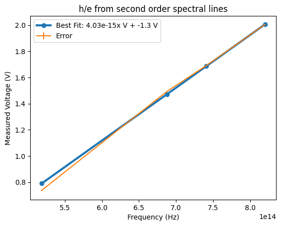

```
The value of b for the best fit line is -1.3.
The value of m for the best fit line is 4e-15.
The uncertainty of b for the best fit line is 0.012.
The uncertainty of m for the best fit line is 1.5e-17.
h{n=1} = 6.463650966667883e-34 J*s
WorkF = 2.087301815277926e-19 J
The accepted value for h is 6.62607015e-34
Relative error: -0.024512143647032837
```

```python
freqs = np.array([5.18672e14, 6.87858e14, 7.40858e14, 8.20264e14]) #Hz

order1_1 = [0.715, 1.472, 1.693, 2.012]
order1_2 = [0.717, 1.478, 1.695, 2.022]
order2_1 = [0.742, 1.496, 1.693, 2.006]
order2_2 = [0.733, 1.492, 1.688, 2.005]

order1_agv = mean(np.array([order1_1, order1_2]))
order1_std = std(np.array([order1_1, order1_2]))
order2_agv = mean(np.array([order2_1, order2_2]))
order2_std = std(np.array([order2_1, order2_2]))

# first order

x = freqs
y = order1_agv
stds = order1_std

args = (x, y, stds)
f = fit_line(*args)
m = m_fit(*args)
b = b_fit(*args)

plt.plot(x, f(x), "-o",  linewidth=3)
plt.errorbar(x, y, stds)
plt.title("h/e from first order spectral lines")
plt.legend([f"Best Fit: {m:.3}x V + {b:.3} V", "Error"])
plt.xlabel("Frequency (Hz)")
plt.ylabel("Measured Voltage (V)")
plt.show()

print(f"The value of b for the best fit line is {b_fit(x, y, stds):.2}.")
print(f"The value of m for the best fit line is {m_fit(x, y, stds):.2}.")
m = m_fit(x, y, stds)

print(f"The uncertainty of b for the best fit line is {sigma_b(x, y, stds):.2}.")
print(f"The uncertainty of m for the best fit line is {sigma_m(x, y, stds):.2}.")

e = 1.602176634e-19
h = m * e
workF = -b * e
print(f"h{{n=1}} = {h} J*s")
print(f"WorkF = {workF} J")

h_real = 6.62607015e-34

print(f"The accepted value for h is {h_real}")
print(f"Relative error: {(h_real-h)/h_real}")

# second order
x = freqs
y = order2_agv
stds = order2_std

args = (x, y, stds)
f = fit_line(*args)
m = m_fit(*args)
b = b_fit(*args)

plt.plot(x, f(x), "-o",  linewidth=3)
plt.errorbar(x, y, stds)
plt.title("h/e from second order spectral lines")
plt.legend([f"Best Fit: {m:.3}x V + {b:.3} V", "Error"])
plt.xlabel("Frequency (Hz)")
plt.ylabel("Measured Voltage (V)")
plt.show()

print(f"The value of b for the best fit line is {b_fit(x, y, stds):.2}.")
print(f"The value of m for the best fit line is {m_fit(x, y, stds):.2}.")
m = m_fit(x, y, stds)

print(f"The uncertainty of b for the best fit line is {sigma_b(x, y, stds):.2}.")
print(f"The uncertainty of m for the best fit line is {sigma_m(x, y, stds):.2}.")

e = 1.602176634e-19
h = m * e
workF = -b * e
print(f"h{{n=1}} = {h} J*s")
print(f"WorkF = {workF} J")

h_real = 6.62607015e-34

print(f"The accepted value for h is {h_real}")
print(f"Relative error: {(h-h_real)/h_real}")
```